# Travaux dirigés 2 - MAP201, thème équation différentielles

Le TP est à faire en python, où la réponse à chaque question est dans une cellule séparée. On veillera à écrire un code suffisamment clair pour être éventuellement réutilisé d'un exercice à l'autre.

```python
!jupyter nbconvert --to html TP_MAP201_2025_EDO_2.ipynb
```

```python
import numpy as np #importe les outils de gestion des tableaux
import matplotlib.pyplot as plt #importe les outils d'affichages matplotlib
plt.rcParams['figure.dpi'] = 120 #reglage facultatif de résolution des figures
```

## Exercice 1 - Etude de x'=sin(x)

Soit $x:\R\to\R$ une solution de l'équation $\dot{x}(t)=\sin(x(t))$, avec $x(0)\in ]0,\pi[$.

### 1)

Quelle est le sens de variation et la limite de $x(t)$ en $t\to +\infty$, en $t\to -\infty$ ?

Réponse:

- en $t\to +\infty$ la limite est $\pi$ car dans cet intervalle la fonction est strictement croissante et tend vers le point d’équilibre $\pi$
- en $t\to -\infty$ la limite est 0 car dans ce cas la fonction est strictement décroissante et tend vers le point d’équilibre 0

### 2)

Pour quelle valeur de $x(t)$ la vitesse $\dot{x}(t)$ est-elle maximale ?

Réponse:

- $\dot{x}(t)$ atteint un maximum lorsque $\sin(x(t))$ est maximal, donc lorsque $\sin(x(t))$ = 1. Pour x dans l’intervalle [0, $\pi$], la valeur de x(t) pour laquelle la vitesse est maximale est $\pi$ / 2

### 3)

Donner une expression de $\ddot{x}(t)$ en fonction de la valeur $x(t)$. Pour quelle valeur de $x(t)$ l'accélération $\ddot{x}(t)$ est-elle maximale ?

Réponse:

- $\ddot{x}(t)$ = d/dt [ $\dot{x}(t)$ ] = d/dt [ $\sin(x(t))$ ] = $\cos(x(t))$ * $\sin(x(t))$ = 1/2 $\sin(2x(t))$
- 1/2 $\sin(2x(t))$ = 1 (maximum) quand 2x = $\pi$/2 donc x = $\pi$/4 est le valeur pour lequel accelerations est maximale

## Exercice 2 - Etude du pendule.

On considère un pendule de longueur $\ell=2$ (mètre), $x(t)$ représente l'angle formé entre la tige du pendule et la verticale à l'instant $t$ ($x=0$ correspond à la position au repos). Le pendule est laché au temps $t=0$ à un angle $x_0\in \R$, à vitesse nulle. L'évolution de $t\mapsto x(t)$ est donnée par l'équation

$$ \begin{cases} \ddot{x}(t)=-\frac{g}{\ell}\sin(x(t))\\ x(0)=x_0, \dot{x}(0)=0 \end{cases}$$

où $g=9.81 m.s^{-2}$ est l'intensité de la pesanteur.

### 1)

Réécrire l'équation différentielle d'ordre $2$ vérifiée par $x(t)$ comme un système différentielle de la forme $\begin{cases}\dot{x}(t)=f(t,x(t),y(t))\\ \dot{y}(t)=h(t,x(t),y(t))\end{cases}$.

Réponse:

- $\dot{x}(t)$ = ${y}(t)$
- $\dot{y}(t)$ = $\ddot{x}(t)$ = - $\frac{g}{\ell}\sin(x(t))$

### 2)

Ecrire une fonction qui prend en entrée une condition initiale $x_0\in \R$, un temps final $T_{fin}>0$, un nombre de pas $N\in\mathbb{N}$, et renvoie trois tableaux $T=[t_0,...,t_N],X=[x_0,..,x_N],Y=[y_0,..,y_N]$, tel que $t_i=iT/N$ et $(x_i,y_i)$ est l'approximation de $(x(t_i),y(t_i))$ au temps $t_i$ obtenue par méthode d'Euler appliquée à l'équation de $x(t),y(t)$.

```python
#Réponse:

def Euler(x0, Tfin, N):
    td = Tfin / N
    g = 9.81
    l = 2
    T=np.linspace(0,Tfin,N+1)
    X=np.zeros(N+1)
    Y=np.zeros(N+1)

    X[0]=x0
    Y[0]=0

    for i in range (N):
        X[i+1] = X[i] + td * Y[i]
        Y[i+1] = Y[i] - td * (g / l) * np.sin(X[i])

    return T, X, Y
```

### 3)

On fixe un temps final $T=6$. Afficher les solutions obtenues pour les conditions initiales $x_0\in \{-5,-4,...,5\}$, avec un nombre de pas suffisament grand.

On affichera dans une première fenètre les graphes de $x(t)$ en fonction de $t$, et dans une seconde fenêtre les tracés des courbes $\{(x(t),y(t)), t\in [0,T]\}$.

[figure not shown]

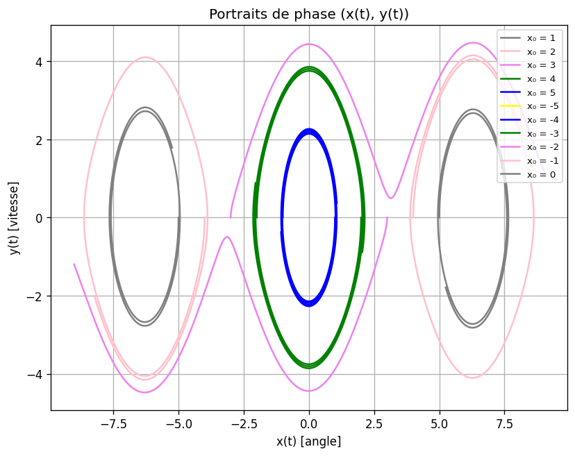

```python
#Réponse:
N=1000
Tfin = 6
x0 = np.arange(-5, 6, 1)
colors = ["gray","pink", "violet", "green", "blue", "yellow", "blue", "green","violet", "pink", "gray"]

# fig 1 - x(t)
plt.figure(figsize=(8,6))
c=0
for i in x0:
    T,X,Y = Euler(i, Tfin, N)
    plt.plot(T,X, label=f'x₀ = {x0[i]}', linestyle="-", color=colors[c])
    c = c + 1

plt.title("Evolution de x(t) pour différentes conditions initiales")
plt.xlabel("t")
plt.ylabel("x(t) [angle]")
plt.grid(True)
plt.legend(loc="upper right", fontsize=8)


# fig 2 - (x(t), y(t))
plt.figure(figsize=(8,6))
c=0
for i in x0:
    T,X,Y = Euler(i, Tfin, N)
    plt.plot(X, Y, label=f'x₀ = {x0[i]}', linestyle="-", color=colors[c])
    c = c + 1
plt.title("Portraits de phase (x(t), y(t))")
plt.xlabel("x(t) [angle]")
plt.ylabel("y(t) [vitesse]")
plt.grid(True)
plt.legend(loc="upper right", fontsize=8)
```

### 4)

On admet le résultat suivant: lorsque $x(0)\in ]0,\pi[$, $\dot{x}(0)=0$, alors la période de $t\mapsto x(t)$ est la plus petite valeur pour laquelle $\dot{x}(t)$ passe de positif à négatif. Ecrire une fonction prenant en entrée un nombre $x_0>0$, qui calcule la période $P(x_0)$ de la solution associée à la condition initiale $x(0)=x_0,\dot{x}(0)=0$.

```python
#Réponse:
def P(x0, Tfin, N):
    #T, X, Y = Euler(x0, Tfin, N)
    td = Tfin / N
    g = 9.81
    l = 2
    T=np.linspace(0,Tfin,N+1)
    X=np.zeros(N+1)
    Y=np.zeros(N+1)

    X[0]=x0
    Y[0]=0

    for i in range (N):
        X[i+1] = X[i] + td * Y[i]
        Y[i+1] = Y[i] - td * (g / l) * np.sin(X[i])

        if Y[i] > 0 and Y[i+1] <= 0: # passage de + a -
            return T[i]

    return Tfin  # aucun changement
```

## 5)

Afficher le graphe de $P(x_0)$ en fonction de $x_0$, pour $x_0$ parcourant une subdivision suffisament fine de l'intervalle $]0,\pi/2]$. On pourra tracer sur la même figure la formule asymptotique $$P_{asymptotic}(x_0)=2\pi\sqrt{\frac{\ell}{g}}\left(1+\frac{x_0^2}{16}\right)$$ et comparer les deux.

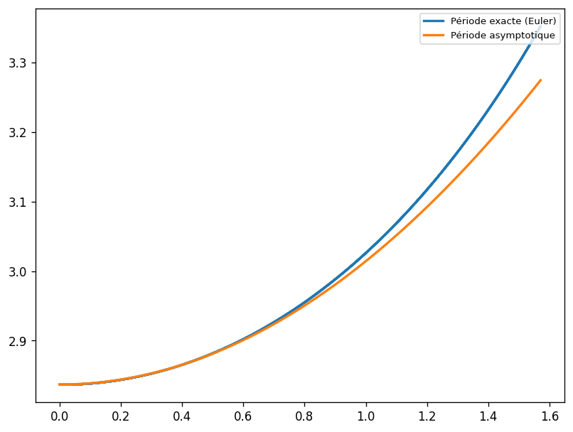

```python
#Réponse:
def Pa(x0):
    g = 9.81
    l = 2
    return 2 * np.pi * (l/g)**(1/2)*(1+ (x0**2/16))

Tfin=10
N=10000
x0 = np.linspace(0, np.pi /2, N+1)
Px0 = np.zeros(N+1)
Pas = np.zeros(N+1)

for i in range(1, N+1):
    Px0[i]=P(x0[i], Tfin, N)
    Pas[i]=Pa(x0[i])

plt.figure(figsize=(8,6))
plt.plot(x0[1:], Px0[1:], linestyle="-", label="Période exacte (Euler)", linewidth=2)
plt.plot(x0[1:], Pas[1:], linestyle="-", label="Période asymptotique", linewidth=2)
plt.legend(loc="upper right", fontsize=8)
```

## Exercice 3 - Modèle d'épidémie.

On considère une population de $S$ individus sains où l'on introduit à l'instant $t=0$, une population de $m$ individus malades. On suit ensuite l'évolution de l'épidémie en divisant la population en trois parties distinctes:

- $x(t)$: la population d'individus sains, qui vérifie $x(0)=S(>0)$.
- $y(t)$: la population d'individus malades, qui vérifie $y(0)=m(>0)$.
- $z(t)$: la population d'individus qui sont guéris et immunisés de la maladie. A l'instant $t=0$ on a $z(0)=0$.

On suppose que $x(t),y(t),z(t)$ suivent une évolution du type $$\begin{cases} \dot{x}(t)=-k\frac{y(t)}{x(t)+y(t)+z(t)}x(t) & (1)\\ \dot{y}(t)=k\frac{y(t)}{x(t)+y(t)+z(t)}x(t)-\ell y(t) & (2)\\ \dot{z}(t)= \ell y(t) & (3) \end{cases}$$ où $k,\ell>0$ sont des paramètres de la maladie.

### 1)

Donner une interprétation de chaque terme du modèle. Que peuvent représenter les quantités $k,\ell $ ?

Réponse:

- k : Taux de transmission
- l : Taux de guérison

### 2)

Grâce à une méthode d'Euler, calculer les solutions et tracer le graphe de $x(t),y(t),z(t)$ en fonction de $t$, pour les paramètres suivants:

$$S=100, m=1,k=6, \ell=3$$

On utilisera un nombre de pas $N$ suffisamment grand. On pensera a bien annoter chaque courbe, et à afficher le graphe sur un temps suffisamment grand pour observer toute l'évolution de $x,y,z$. Par lecture graphique, quel est le sens de variation et le comportement asymptotique de $x(t),y(t),z(t)$ ? On pourra aussi calculer leur valeur limites et extrémales.

```
Finales:

20.21562105093846

0.07505417616646962

80.70932477289504

Maximales:

100.0

16.010137804428926

80.70932477289504
```

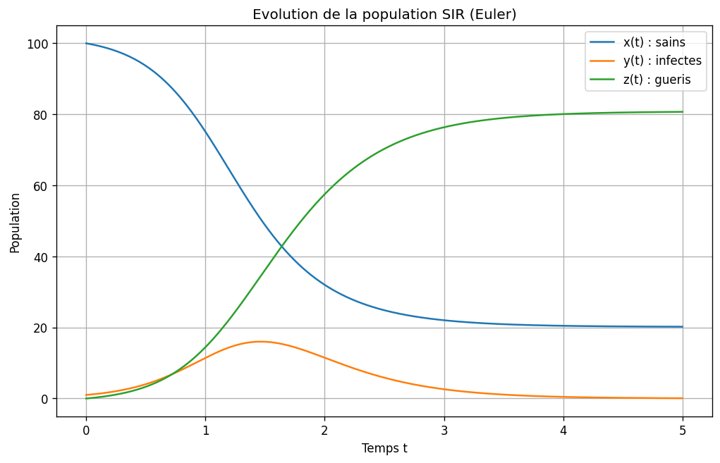

```python
S = 100
m = 1
k = 6
lmbda = 3
Tfin = 5
N = 5000
dt = Tfin / N

T = np.linspace(0, Tfin, N + 1)
X = np.zeros(N + 1)
Y = np.zeros(N + 1)
Z = np.zeros(N + 1)

X[0] = S
Y[0] = m
Z[0] = 0

for i in range(N):
    total = X[i] + Y[i] + Z[i]
    dX = -k * (Y[i] / total) * X[i]
    dY = -dX - lmbda * Y[i]
    dZ = lmbda * Y[i]

    X[i + 1] = X[i] + dt * dX
    Y[i + 1] = Y[i] + dt * dY
    Z[i + 1] = Z[i] + dt * dZ

plt.figure(figsize=(10, 6))
plt.plot(T, X, label='x(t) : sains')
plt.plot(T, Y, label='y(t) : infectes')
plt.plot(T, Z, label='z(t) : gueris')
plt.title("Evolution de la population SIR (Euler)")
plt.xlabel("Temps t")
plt.ylabel("Population")
plt.grid(True)
plt.legend()

X_final, Y_final, Z_final = X[-1], Y[-1], Z[-1]
X_max, Y_max, Z_max = np.max(X), np.max(Y), np.max(Z)

print("Finales: \n")
print(X_final, "\n")
print(Y_final, "\n")
print(Z_final, "\n")
print("Maximales: \n")
print(X_max, "\n")
print(Y_max, "\n")
print(Z_max, "\n")
```

### 3)

Quels changements observe-t-on si on change $m=1$ en $m=0.1$, $m=0.01$ ? Comment change le tableau de variations des solutions ?

Reponse:

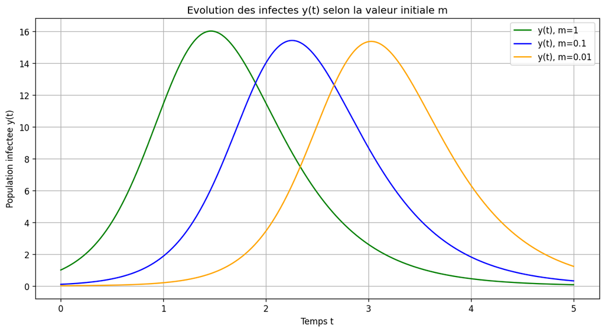

```python
#Réponse:
def sir(m, S=100, k=6, lmbda=3, Tfin=5, N=5000):
    dt = Tfin / N
    T = np.linspace(0, Tfin, N + 1)
    X = np.zeros(N + 1)
    Y = np.zeros(N + 1)
    Z = np.zeros(N + 1)

    X[0] = S
    Y[0] = m
    Z[0] = 0

    for i in range(N):
        total = X[i] + Y[i] + Z[i]
        dX = -k * (Y[i] / total) * X[i]
        dY = -dX - lmbda * Y[i]
        dZ = lmbda * Y[i]

        X[i + 1] = X[i] + dt * dX
        Y[i + 1] = Y[i] + dt * dY
        Z[i + 1] = Z[i] + dt * dZ

    return T, X, Y, Z

m_values = [1, 0.1, 0.01]
colors = ["green", "blue", "orange"]
labels = ['m=1', 'm=0.1', 'm=0.01']

plt.figure(figsize=(12, 6))

for m, color, label in zip(m_values, colors, labels):
    T, X, Y, Z = sir(m)
    plt.plot(T, Y, label=f"y(t), {label}", color=color)

plt.title("Evolution des infectes y(t) selon la valeur initiale m")
plt.xlabel("Temps t")
plt.ylabel("Population infectee y(t)")
plt.grid(True)
plt.legend()
```

### 4)

On étudie maintenant le changement de comportement de la maladie selon les paramètres $k,\ell$. On fixe $$S=100,m=0.1,\ell=4$$ et on va faire varier $k$ sur une subdivision de l'intervalle $[0,10]$. On note $z_{lim}(k)$ la limite de $z(t)$, lorsque $x(t),y(t),z(t)$ est la solution associée au paramètre $k$.

Ecrire une fonction qui renvoie une approximation de $z_{lim}(k)$, et afficher le graphe de $z_{lim}(k)$ en fonction de $k$ pour $k\in [0,10]$. Que constate-t-on ?

Réponse:

- Plus le paramètre k est grand, plus la maladie se propage facilement
- Pour de petites valeurs de k , l’épidémie ne démarre pas

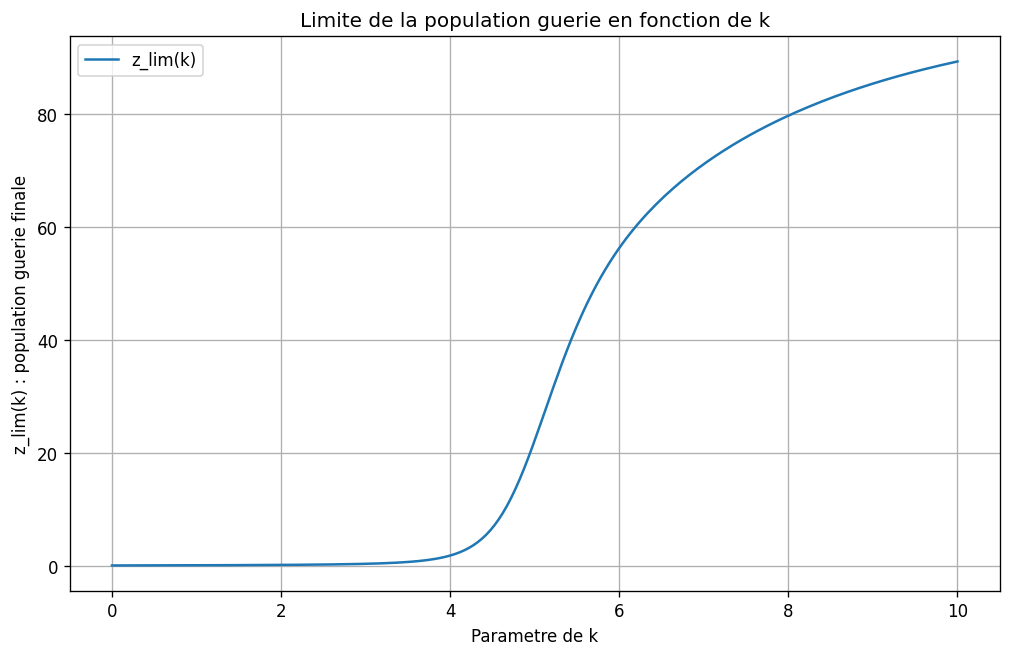

```python
#Réponse:
def z_lim(k, S=100, m=0.1, lmbda=4, Tfin=5, N=5000):
    dt = Tfin / N
    X = np.zeros(N + 1)
    Y = np.zeros(N + 1)
    Z = np.zeros(N + 1)

    X[0] = S
    Y[0] = m
    Z[0] = 0

    for i in range(N):
        total = X[i] + Y[i] + Z[i]
        dX = -k * (Y[i] / total) * X[i]
        dY = -dX - lmbda * Y[i]
        dZ = lmbda * Y[i]

        X[i + 1] = X[i] + dt * dX
        Y[i + 1] = Y[i] + dt * dY
        Z[i + 1] = Z[i] + dt * dZ

    return Z[-1] # on retourne le dernier valeur de Z qui est la nombre finale des persones infectees

k_vals = np.linspace(0, 10, 200)
zlims = [z_lim(k) for k in k_vals]

plt.figure(figsize=(10, 6))
plt.plot(k_vals, zlims, label="z_lim(k)")
plt.title("Limite de la population guerie en fonction de k")
plt.xlabel("Parametre de k")
plt.ylabel("z_lim(k) : population guerie finale")
plt.grid(True)
plt.legend()
```

### 5) (Question ouverte)

Proposer une modification du modèle pour rendre compte d'un mécanisme supplémentaire: les individus guéris et immunisés perdent progressivement leur immunité. La durée d'immunité est supposée typiquement plus longue que la durée de la maladie elle-même.

On pourra représenter l'effet de cette modification du modèle.

Réponse:

- On peut par exemple introduire un paramètre 'a' qui représenterait la perte d’immunité d’une personne guérie, c’est-à-dire qu’elle peut retomber malade.
- Si 'a' est grand, alors l’immunité diminue rapidement, et pour des valeurs très élevées de 'a', l’épidémie peut se répéter de manière cyclique
- On peut aussi introduire un paramètre 'q' représentant la probabilité de décès liée à la maladie.
- Dans le cas d’une maladie ayant un risque de mortalité, la population totale peut diminuer avec le temps, car une certaine proportion des personnes infectées meurt.
- Cette probabilité de décès pourrait aussi être plus faible pour une personne ayant déjà contracté la maladie auparavant.